# **Aprendizaje estadístico-automático**

### **Base de datos:** Obesidad.csv

*¿Qué información te interesaría revisar si formaran parte del equipo de investigación? ¿Qué información te hubiera gustado recopilar y que actualmente no se encuentra en el estudio*

Me hubiera gustado registrar el país del que es cada individuo, además de también si hacen ejercicio o si están bajo una dieta especifica, y si es así cuánto tiemopo la han mantenido hasta la fecha, además me gustaría más saber cuántas calorias come al día/semana/mes aproximadamente en lugar de registrar solo si come muchas calorias o no, de forma similar me gustaría que se hiciera lo mismo con el consumo de agua.

1. Importa los datos del archivo “Obesidad.csv” a tu ambiente de trabajo en una JupyterNotebook y muestra en consola un resumen, imprimiendo las primeras 10 filas de datos.

```python
#Importar librerias
import pandas as pd
import matplotlib.pyplot as plt
#Leer CSV
df = pd.read_csv('Obesidad.csv')
df.head(10)
```

|  | Sexo | Edad | Estatura | Peso | FamiliarConSobrepeso | ComeMuchasCalorias | ComeVegetales | Fumador | ConsumoDeAgua | NivelDeObesidad |
| --- | --- | --- | --- | --- | --- | --- | --- | --- | --- | --- |
| 0 | Female | 21.0 | 1.62 | 64.0 | yes | no | 2.0 | no | 2.0 | Normal_Weight |
| 1 | Female | 21.0 | 1.52 | 56.0 | yes | no | 3.0 | yes | 3.0 | Normal_Weight |
| 2 | Male | 23.0 | 1.80 | 77.0 | yes | no | 2.0 | no | 2.0 | Normal_Weight |
| 3 | Male | 27.0 | 1.80 | 87.0 | no | no | 3.0 | no | 2.0 | Overweight_Level_I |
| 4 | Male | 22.0 | 1.78 | 89.8 | no | no | 2.0 | no | 2.0 | Overweight_Level_II |
| 5 | Male | 29.0 | 1.62 | 53.0 | no | yes | 2.0 | no | 2.0 | Normal_Weight |
| 6 | Female | 23.0 | 1.50 | 55.0 | yes | yes | 3.0 | no | 2.0 | Normal_Weight |
| 7 | Male | 22.0 | 1.64 | 53.0 | no | no | 2.0 | no | 2.0 | Normal_Weight |
| 8 | Male | 24.0 | 1.78 | 64.0 | yes | yes | 3.0 | no | 2.0 | Normal_Weight |
| 9 | Male | 22.0 | 1.72 | 68.0 | yes | yes | 2.0 | no | 2.0 | Normal_Weight |

2. Imprime en consola o genera un cuadro de descripción que muestre un mensaje donde

indiques qué otra variable hubieras decidido medir si formaras parte del grupo d investigación, indicando claramente si la información recopilada se consideraría co o cuantitativa o cualitativa.

```python
print("Para esta investigación habría considerado también el número o la cantidad aporximada de calorias que los individuos consumen aunque sea en un promedio o un aproximado por día.")
```

```
Para esta investigación habría considerado también el número o la cantidad aporximada de calorias que los individuos consumen aunque sea en un promedio o un aproximado por día.
```

3. Si tú fueras el líder del proyecto y quisieras realizar un estudio de inferencia, ¿qué variable

de la base de datos definirías como la salida o respuesta? Aquella variable para la que t interesa encontrar asociaciones específicas. Imprime el promedio de dicha variable, si s cuantitativa, o la cantidad de personas que pertenecen a cada categoría, si es cualitativa.

```python
df['NivelDeObesidad'].value_counts()
```

```
NivelDeObesidad
Obesity_Type_I         351
Obesity_Type_III       324
Obesity_Type_II        297
Overweight_Level_I     290
Overweight_Level_II    290
Normal_Weight          287
Insufficient_Weight    272
Name: count, dtype: int64
```

Lo que deseamos saber cómo ocurre o cómo se explica debería ser el Nivel de Obesidad en los individuos, ya que este es en gran medida el objetivo de recopilar estos datos en primer lugar.

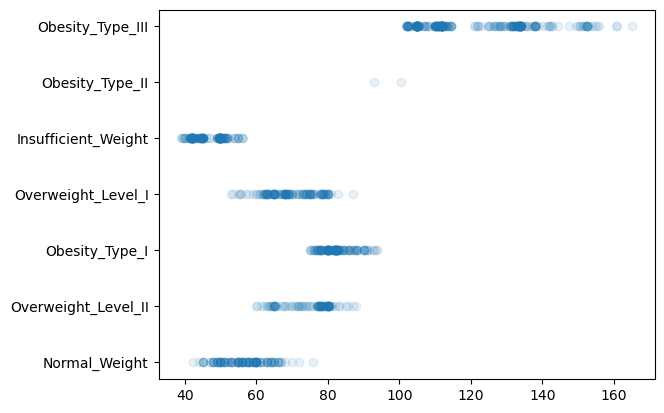

```python
dfny = df[['Peso', 'NivelDeObesidad']][df['Sexo'] == 'Female']
plt.scatter(dfny['Peso'], dfny['NivelDeObesidad'], alpha=0.1)
```

Con la gráfica anterior se puede observar que las mujeres casi no presentan Obesidad Tipo II, y presentan mayormente Obesidad Tipo III o un peso normal.

*"Doy mi palabra de que he realizado esta actividad con integirdad académica"*